# Workbook

Model Evaluation

2021-06-03

# 1 Preliminaries for R examples

```r
library(tidyverse)
library(stringr)
library(haven)
library(GGally)
library(binom)
library(texreg)
library(mgcv)
library(DHARMa)

expit <- function(x) 1 / (1+exp(-x))

theme_set(theme_bw())
```

```r
# Preamble of data assembly and model fitting done in previous workbooks

load('../data/aedat.RDS')
source("preprocess_data.R")

mod01 <- glm(AE01 ~ CAVGSS + PTTYPE,
             family = binomial(link = "logit"),
             data = aedat,
             )

ref_bwt <- median(aedat$BWT) # will want reference value later, so save as variable!
dat_mod <- aedat %>% mutate(
  BWT_norm = BWT - ref_bwt,
  PTTYPE = factor(PTTYPE, levels = c("PT1", "PT2", "HV"))
)

mod03 <- glm(AE01 ~ CAVGSS + PTTYPE + BWT_norm,
             family = binomial(link = "logit"),
             data = dat_mod,
             )
```

# 2 Workbook: Model evaluation and comparison

## 2.1 Residual plot

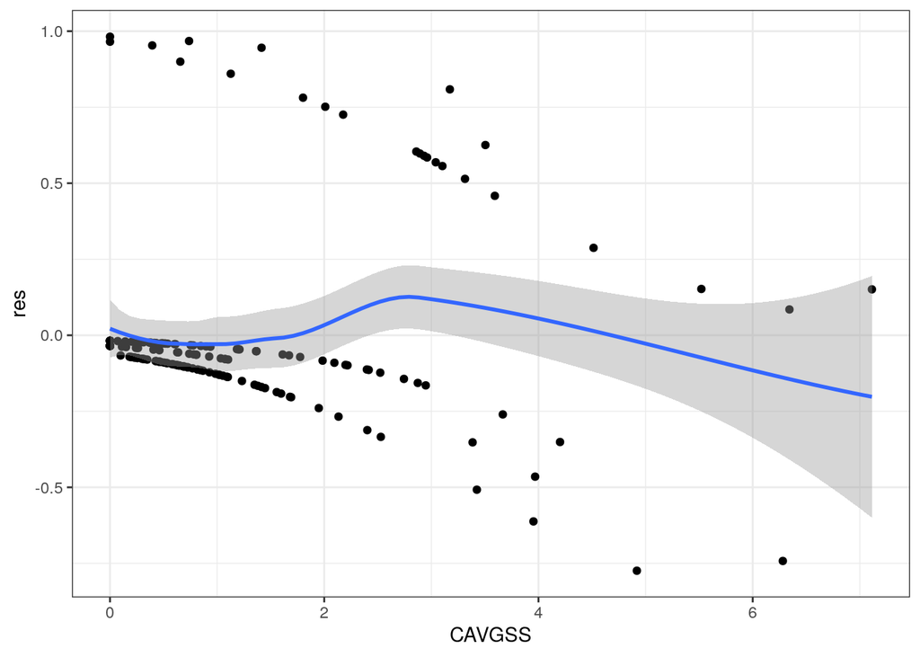

```r
dat_plus <- dat_mod
dat_plus$res <- residuals(mod01, type = "response")
dat_plus$pred <- fitted(mod01)

resplot <-
  ggplot(dat_plus, aes(x = CAVGSS, y = res)) +
  geom_point() +
  geom_smooth()

resplot
```

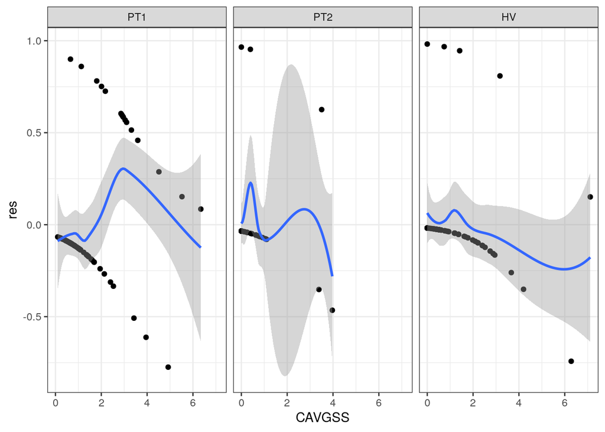

```r
resplot + facet_wrap(~ PTTYPE)
```

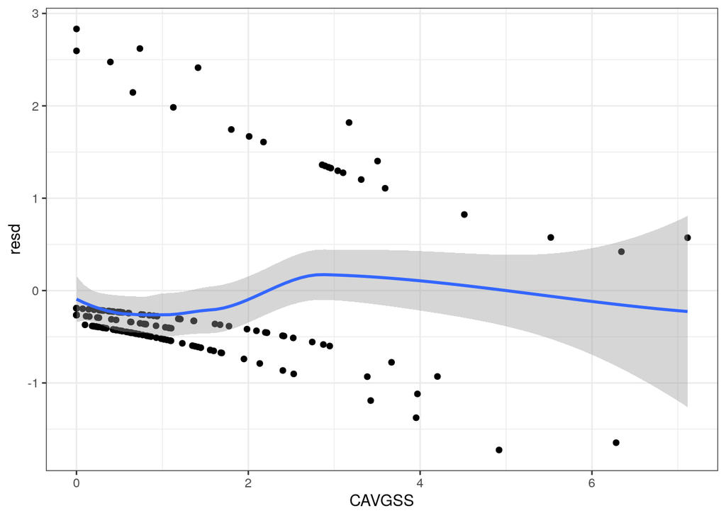

```r
# deviance residuals
dat_plus$resd <- residuals(mod01, type = "deviance")
dat_plus$pred <- fitted(mod01)

resplot <-
  ggplot(dat_plus, aes(x = CAVGSS, y = resd)) +
  geom_point() +
  geom_smooth()

resplot
```

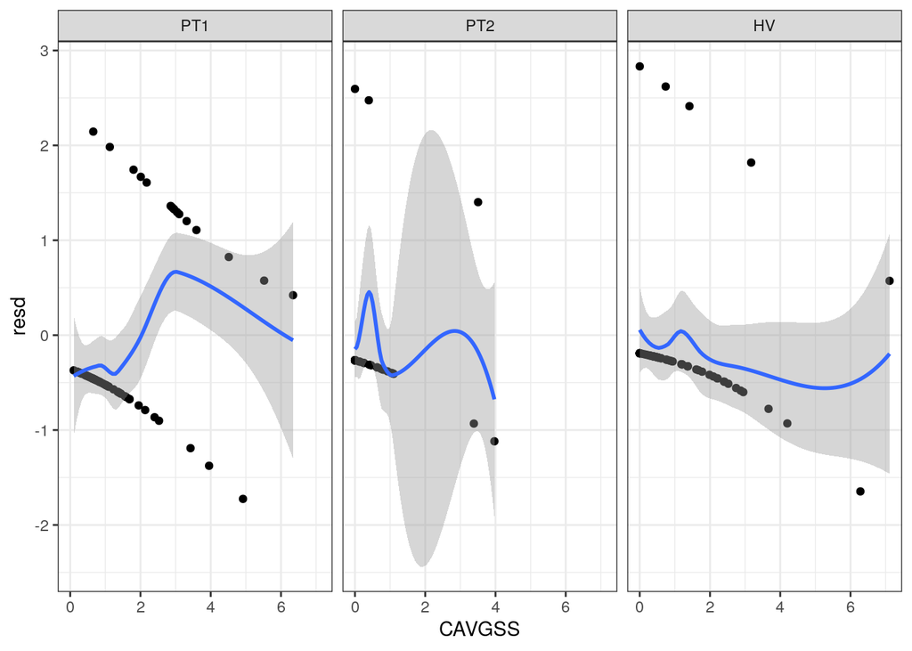

```r
resplot + facet_wrap(~ PTTYPE)
```

Suggestive of:

- Over-predicting rates for HV at high exposures.
- Possibly underpredicting at mid-range exposures for `PT1`.

Exercise: Plot residuals by `BWT`, faceting by `STUDYID`.

*Extra credit Exercise:*

Binned residuals are another way to smooth out the discreteness in binary residuals. The general algorithm is to:

1. Bin the data by fitted value
2. Within each bin, calculate the average
   - residual
   - fitted probability of the outcome
   - continuous covariate values
3. Plot the average residual (y axis) against the other average metrics per bin
4. Include thresholds for the residuals at +/- 2*sqrt(p_bin(1-p_bin)/n_bin), where p_bin is the fitted probability

# 3 DHARMa residuals

The simulareResiduals function in the DHARMa package calculates the smoothed quantile residuals

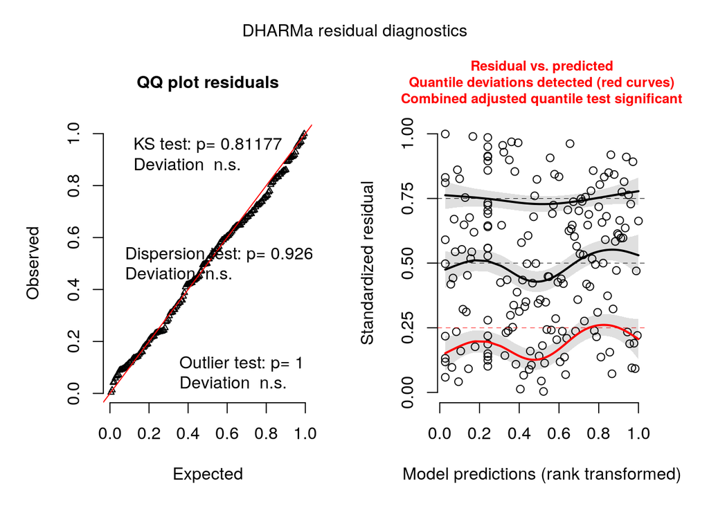

```r
simulationOutput = DHARMa::simulateResiduals(mod01, n = 1000)
plot(simulationOutput)
```

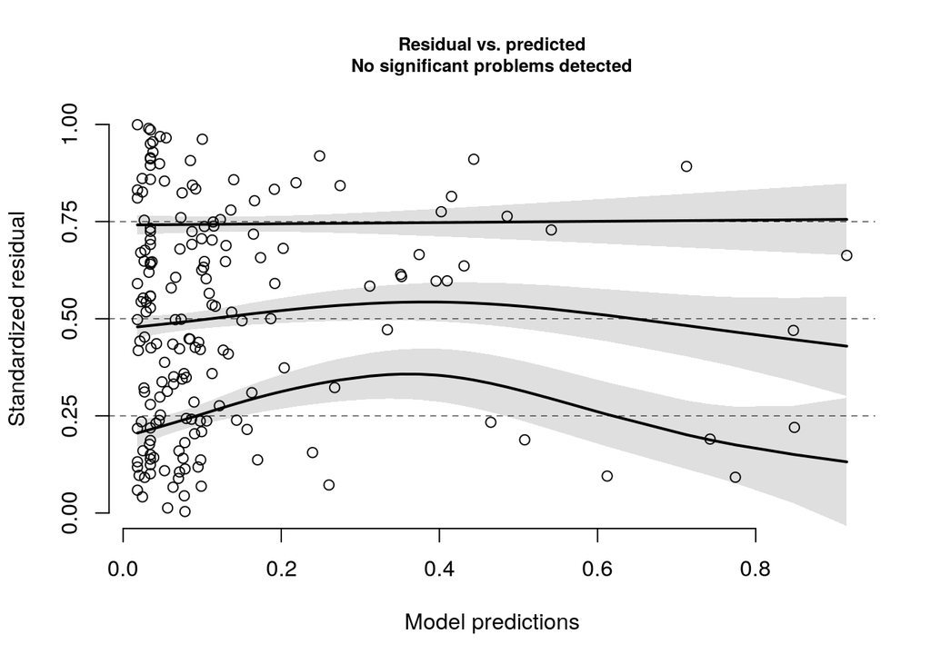

```r
DHARMa::plotResiduals(simulationOutput)
```

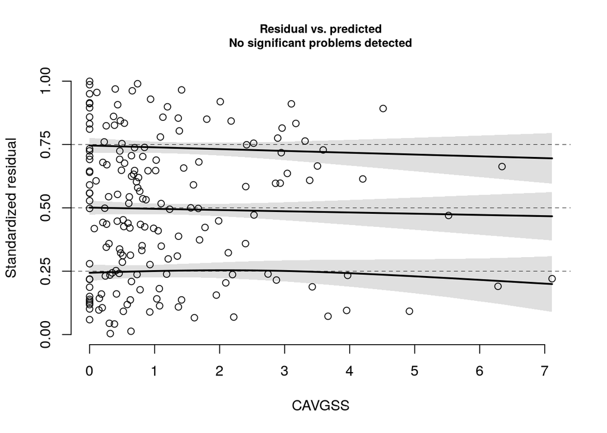

```r
DHARMa::plotResiduals(simulationOutput,form=dat_mod$CAVGSS,xlab="CAVGSS")
```

## 3.1 VPC vs a categorical covariate

First, we’ll simulate some data.

```r
# Simulate using the simulate function in stats
aedat_pp = bind_cols(aedat,
                     stats::simulate(mod03, nsim=500)) %>%
  pivot_longer(cols=sim_1:sim_500, values_to='value', names_to='name')
```

Look at the simulated data and the help file for the stats::simulate function. Do you understand the structure of the data?

Let’s make a categorical VPC for percent of subjects with a severe AE by exposure quartile.

```r
# Define the summary statistic
vpc_statistic <- function(x) sum(x, na.rm = TRUE) / sum(!is.na(x))
```

Now, we’ll apply the summary function to the observed data and plot the results for reference. (We’ll add the simulation-based values next.)

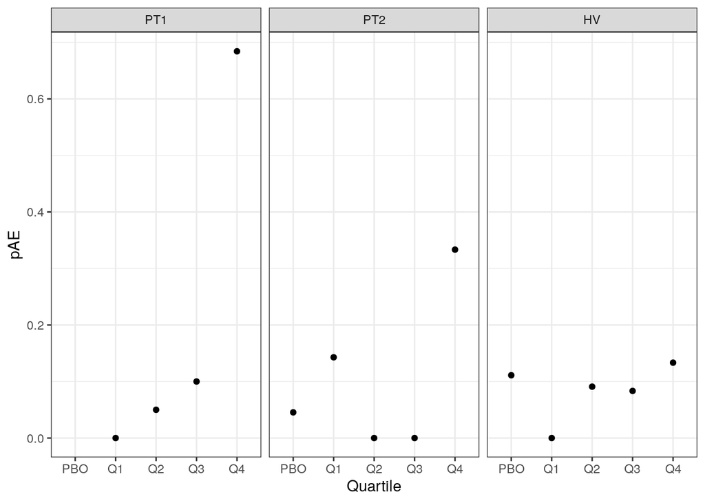

```r
obs_stat <- dat_mod %>%
  group_by(PTTYPE, Quartile) %>%
  summarise(pAE = vpc_statistic(AE01)) %>%
  mutate(type='Observed')


ggplot(obs_stat) +
  geom_point(aes(x = Quartile, y = pAE)) +
  facet_wrap(~ PTTYPE)
```

Next, we’ll apply the same summary function to each simulated dataset.

```r
#Simulated data summary
sim_summary <- aedat_pp %>%
  group_by(name,PTTYPE,Quartile) %>%
  summarise(pAE = vpc_statistic(value)) %>%
  mutate(type='Predicted')
```

Look at the summary od the simulated data. Do you understand the format and how we got here?

Now let’s put together the pieces for plotting

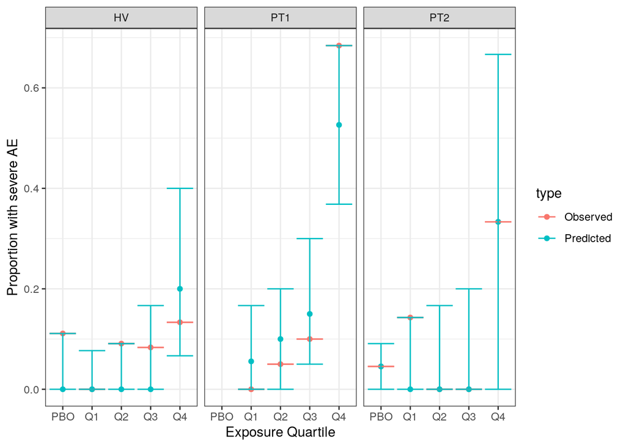

```r
comb_stat <- sim_summary %>%
  bind_rows(obs_stat) %>%
  group_by(type,PTTYPE, Quartile) %>%
  summarise(phat = median(pAE),
            lcl = quantile(pAE, probs = 0.05),
            ucl = quantile(pAE, probs = 0.95))

  comb_stat %>%
  ggplot(aes(x=Quartile, y=phat, group=type, col=type)) +
    geom_point() +
    geom_errorbar(aes(ymin=lcl, ymax=ucl)) +
    facet_wrap(~PTTYPE) +
    labs(y='Proportion with severe AE', x='Exposure Quartile')
```

Exercise: Create a VPC for the proportion of patients with a severe AE within each gender.

## 3.2 VPC against continuous predictors

- Summary statistic = non-parametric estimate of exposure-response relationship, evaluated at a fixed grid of values
  - Fit generalized additive model (smoother) to each simulated dataset
  - Predict at a fixed grid of values (5$^{th}$ to 95$^{th}$ percentile)

```r
summary_function <- function(.data, .x_name, .y_name='value') {
  .data <- .data %>% ungroup() %>% rename('xvar' = .x_name, 'yvar'=.y_name)
  x_grid <- with(.data, seq(from = quantile(xvar, probs=0.05),
                           to = quantile(xvar,probs = 0.95),
                           length = 100))
  fit <- gam(yvar ~ s(xvar), family=binomial(link='logit'), data=.data)
  predictions <- predict(fit, newdata = data.frame(xvar=x_grid), type='response')
  return( data.frame(xvar=x_grid, prediction = predictions))
}
```

Compute summary statistics for observed data

```r
obs_summary <- summary_function(aedat, .x_name = 'CAVGSS', .y_name='AE01') %>%
  mutate(type='Observed')

head(obs_summary)
```

```
.         xvar prediction     type
. 1 0.00000000 0.03526032 Observed
. 2 0.03718346 0.03644987 Observed
. 3 0.07436693 0.03767799 Observed
. 4 0.11155039 0.03894582 Observed
. 5 0.14873385 0.04025454 Observed
. 6 0.18591731 0.04160537 Observed
```

Compute summary on each simulated study

```r
sim_summary <- aedat_pp %>%
  # Nest everying except the simulation name
  nest(cols=-name) %>%
  # Use 200 sims for demonstration
  slice(1:200) %>%
  # Compute summary stats for each simulated dataset
  mutate(predictions = map(cols, ~summary_function(.x, .x_name='CAVGSS'))) %>%
  select(name, predictions) %>%
  unnest(cols=predictions) %>%
  # Summarise across simulated data sets
  group_by(xvar) %>%
  summarise(qlo = quantile(prediction, probs = 0.05),
            qhi = quantile(prediction, probs = 0.95),
            prediction=median(prediction)
            ) %>%
  mutate(type = 'Simulated')
```

Combine and plot

```r
sim_summary %>% bind_rows(obs_summary) %>%
  ggplot(aes(x=xvar, y=prediction)) +
  geom_line(aes(col=type, group=type)) +
  geom_ribbon(aes(ymin=qlo, ymax=qhi, fill=type), alpha=0.2) +
  labs(x='Steady-state Cavg', y='Probability of severe AE')
```

[output not shown]

Exercise: Make a similar VPC plotted against bodyweight.

Extended Exercise:

- Re-fit the first model (mod01) to allow a different slope of exposure-response relationship for each level of `PTTYPE`. (Hint: the formula will be AE01 ~ CAVGSS*PTTYPE)
- Re-generate the residual and VPCs and compare the results.
- Read `?aic` and compare the models with and without interaction in terms of AIC.